# Risk Factor Analysis

## Outcome Variable

**Outcome Variable:** ever_wasted

## Predictor Variables

**Intervention Variable:** hhwealth_quart

**Adjustment Set:**

- arm
- sex
- W_mage
- meducyrs
- feducyrs
- W_gagebrth
- W_birthwt
- W_birthlen
- W_nchldlt5
- W_parity
- delta_W_mage
- delta_meducyrs
- delta_feducyrs
- delta_W_gagebrth
- delta_W_birthwt
- delta_W_birthlen
- delta_W_nchldlt5
- delta_W_parity

## Stratifying Variables

The analysis was stratified on these variable(s):

- agecat
- studyid
- country

## Data Summary

| agecat | studyid | country | hhwealth_quart | ever_wasted | n_cell | n |
| --- | --- | --- | --- | --- | --- | --- |
| 0-24 months | ki0047075b-MAL-ED | BANGLADESH | Wealth Q4 | 0 | 44 | 242 |
| 0-24 months | ki0047075b-MAL-ED | BANGLADESH | Wealth Q4 | 1 | 17 | 242 |
| 0-24 months | ki0047075b-MAL-ED | BANGLADESH | Wealth Q1 | 0 | 40 | 242 |
| 0-24 months | ki0047075b-MAL-ED | BANGLADESH | Wealth Q1 | 1 | 20 | 242 |
| 0-24 months | ki0047075b-MAL-ED | BANGLADESH | Wealth Q2 | 0 | 36 | 242 |
| 0-24 months | ki0047075b-MAL-ED | BANGLADESH | Wealth Q2 | 1 | 25 | 242 |
| 0-24 months | ki0047075b-MAL-ED | BANGLADESH | Wealth Q3 | 0 | 38 | 242 |
| 0-24 months | ki0047075b-MAL-ED | BANGLADESH | Wealth Q3 | 1 | 22 | 242 |
| 0-24 months | ki0047075b-MAL-ED | BRAZIL | Wealth Q4 | 0 | 44 | 210 |
| 0-24 months | ki0047075b-MAL-ED | BRAZIL | Wealth Q4 | 1 | 9 | 210 |
| 0-24 months | ki0047075b-MAL-ED | BRAZIL | Wealth Q1 | 0 | 48 | 210 |
| 0-24 months | ki0047075b-MAL-ED | BRAZIL | Wealth Q1 | 1 | 5 | 210 |
| 0-24 months | ki0047075b-MAL-ED | BRAZIL | Wealth Q2 | 0 | 50 | 210 |
| 0-24 months | ki0047075b-MAL-ED | BRAZIL | Wealth Q2 | 1 | 3 | 210 |
| 0-24 months | ki0047075b-MAL-ED | BRAZIL | Wealth Q3 | 0 | 48 | 210 |
| 0-24 months | ki0047075b-MAL-ED | BRAZIL | Wealth Q3 | 1 | 3 | 210 |
| 0-24 months | ki0047075b-MAL-ED | INDIA | Wealth Q4 | 0 | 34 | 235 |
| 0-24 months | ki0047075b-MAL-ED | INDIA | Wealth Q4 | 1 | 25 | 235 |
| 0-24 months | ki0047075b-MAL-ED | INDIA | Wealth Q1 | 0 | 26 | 235 |
| 0-24 months | ki0047075b-MAL-ED | INDIA | Wealth Q1 | 1 | 34 | 235 |
| 0-24 months | ki0047075b-MAL-ED | INDIA | Wealth Q2 | 0 | 28 | 235 |
| 0-24 months | ki0047075b-MAL-ED | INDIA | Wealth Q2 | 1 | 30 | 235 |
| 0-24 months | ki0047075b-MAL-ED | INDIA | Wealth Q3 | 0 | 33 | 235 |
| 0-24 months | ki0047075b-MAL-ED | INDIA | Wealth Q3 | 1 | 25 | 235 |
| 0-24 months | ki0047075b-MAL-ED | NEPAL | Wealth Q4 | 0 | 42 | 236 |
| 0-24 months | ki0047075b-MAL-ED | NEPAL | Wealth Q4 | 1 | 17 | 236 |
| 0-24 months | ki0047075b-MAL-ED | NEPAL | Wealth Q1 | 0 | 37 | 236 |
| 0-24 months | ki0047075b-MAL-ED | NEPAL | Wealth Q1 | 1 | 22 | 236 |
| 0-24 months | ki0047075b-MAL-ED | NEPAL | Wealth Q2 | 0 | 47 | 236 |
| 0-24 months | ki0047075b-MAL-ED | NEPAL | Wealth Q2 | 1 | 12 | 236 |

[output cut: 402 more lines]

The following strata were considered:

- agecat: 0-24 months, studyid: ki0047075b-MAL-ED, country: BANGLADESH
- agecat: 0-24 months, studyid: ki0047075b-MAL-ED, country: BRAZIL
- agecat: 0-24 months, studyid: ki0047075b-MAL-ED, country: INDIA
- agecat: 0-24 months, studyid: ki0047075b-MAL-ED, country: NEPAL
- agecat: 0-24 months, studyid: ki0047075b-MAL-ED, country: PERU
- agecat: 0-24 months, studyid: ki0047075b-MAL-ED, country: SOUTH AFRICA
- agecat: 0-24 months, studyid: ki0047075b-MAL-ED, country: TANZANIA, UNITED REPUBLIC OF
- agecat: 0-24 months, studyid: ki1000108-CMC-V-BCS-2002, country: INDIA
- agecat: 0-24 months, studyid: ki1000108-IRC, country: INDIA
- agecat: 0-24 months, studyid: ki1017093b-PROVIDE, country: BANGLADESH
- agecat: 0-24 months, studyid: ki1066203-TanzaniaChild2, country: TANZANIA, UNITED REPUBLIC OF
- agecat: 0-24 months, studyid: ki1113344-GMS-Nepal, country: NEPAL
- agecat: 0-24 months, studyid: ki1114097-CONTENT, country: PERU
- agecat: 0-24 months, studyid: ki1135781-COHORTS, country: GUATEMALA
- agecat: 0-24 months, studyid: ki1135781-COHORTS, country: PHILIPPINES
- agecat: 0-24 months, studyid: ki1148112-LCNI-5, country: MALAWI
- agecat: 0-24 months, studyid: kiGH5241-JiVitA-3, country: BANGLADESH
- agecat: 0-24 months, studyid: kiGH5241-JiVitA-4, country: BANGLADESH
- agecat: 0-6 months, studyid: ki0047075b-MAL-ED, country: BANGLADESH
- agecat: 0-6 months, studyid: ki0047075b-MAL-ED, country: BRAZIL
- agecat: 0-6 months, studyid: ki0047075b-MAL-ED, country: INDIA
- agecat: 0-6 months, studyid: ki0047075b-MAL-ED, country: NEPAL
- agecat: 0-6 months, studyid: ki0047075b-MAL-ED, country: PERU
- agecat: 0-6 months, studyid: ki0047075b-MAL-ED, country: SOUTH AFRICA
- agecat: 0-6 months, studyid: ki0047075b-MAL-ED, country: TANZANIA, UNITED REPUBLIC OF
- agecat: 0-6 months, studyid: ki1000108-CMC-V-BCS-2002, country: INDIA
- agecat: 0-6 months, studyid: ki1000108-IRC, country: INDIA
- agecat: 0-6 months, studyid: ki1017093b-PROVIDE, country: BANGLADESH
- agecat: 0-6 months, studyid: ki1066203-TanzaniaChild2, country: TANZANIA, UNITED REPUBLIC OF
- agecat: 0-6 months, studyid: ki1113344-GMS-Nepal, country: NEPAL
- agecat: 0-6 months, studyid: ki1114097-CONTENT, country: PERU
- agecat: 0-6 months, studyid: ki1135781-COHORTS, country: GUATEMALA
- agecat: 0-6 months, studyid: ki1135781-COHORTS, country: PHILIPPINES
- agecat: 0-6 months, studyid: ki1148112-LCNI-5, country: MALAWI
- agecat: 0-6 months, studyid: kiGH5241-JiVitA-3, country: BANGLADESH
- agecat: 0-6 months, studyid: kiGH5241-JiVitA-4, country: BANGLADESH
- agecat: 6-24 months, studyid: ki0047075b-MAL-ED, country: BANGLADESH
- agecat: 6-24 months, studyid: ki0047075b-MAL-ED, country: BRAZIL
- agecat: 6-24 months, studyid: ki0047075b-MAL-ED, country: INDIA
- agecat: 6-24 months, studyid: ki0047075b-MAL-ED, country: NEPAL
- agecat: 6-24 months, studyid: ki0047075b-MAL-ED, country: PERU
- agecat: 6-24 months, studyid: ki0047075b-MAL-ED, country: SOUTH AFRICA
- agecat: 6-24 months, studyid: ki0047075b-MAL-ED, country: TANZANIA, UNITED REPUBLIC OF
- agecat: 6-24 months, studyid: ki1000108-CMC-V-BCS-2002, country: INDIA
- agecat: 6-24 months, studyid: ki1000108-IRC, country: INDIA
- agecat: 6-24 months, studyid: ki1017093b-PROVIDE, country: BANGLADESH
- agecat: 6-24 months, studyid: ki1066203-TanzaniaChild2, country: TANZANIA, UNITED REPUBLIC OF
- agecat: 6-24 months, studyid: ki1113344-GMS-Nepal, country: NEPAL
- agecat: 6-24 months, studyid: ki1114097-CONTENT, country: PERU
- agecat: 6-24 months, studyid: ki1135781-COHORTS, country: GUATEMALA
- agecat: 6-24 months, studyid: ki1135781-COHORTS, country: PHILIPPINES
- agecat: 6-24 months, studyid: ki1148112-LCNI-5, country: MALAWI
- agecat: 6-24 months, studyid: kiGH5241-JiVitA-3, country: BANGLADESH
- agecat: 6-24 months, studyid: kiGH5241-JiVitA-4, country: BANGLADESH

### Dropped Strata

Some strata were dropped due to rare outcomes:

- agecat: 0-24 months, studyid: ki0047075b-MAL-ED, country: BRAZIL
- agecat: 0-24 months, studyid: ki1114097-CONTENT, country: PERU
- agecat: 0-6 months, studyid: ki0047075b-MAL-ED, country: BRAZIL
- agecat: 0-6 months, studyid: ki0047075b-MAL-ED, country: PERU
- agecat: 0-6 months, studyid: ki0047075b-MAL-ED, country: TANZANIA, UNITED REPUBLIC OF
- agecat: 0-6 months, studyid: ki1114097-CONTENT, country: PERU
- agecat: 0-6 months, studyid: ki1148112-LCNI-5, country: MALAWI
- agecat: 6-24 months, studyid: ki0047075b-MAL-ED, country: BRAZIL
- agecat: 6-24 months, studyid: ki0047075b-MAL-ED, country: PERU
- agecat: 6-24 months, studyid: ki0047075b-MAL-ED, country: TANZANIA, UNITED REPUBLIC OF
- agecat: 6-24 months, studyid: ki1114097-CONTENT, country: PERU

## Methods Detail

We’re interested in the causal parameters $E[Y_a]$ for all values of $a \in \mathcal{A}$. These parameters represent the mean outcome if, possibly contrary to fact, we intervened to set all units to have $A=a$. Under the randomization and positivity assumptions, these are identified by the statistical parameters $\psi_a=E_W[E_{Y|A,W}(Y|A=a,W)]$. In addition, we’re interested in the mean of $Y$, $E[Y]$ under no intervention (the observed mean). We will estimate these parameters by using SuperLearner to fit the relevant likelihood factors – $E_{Y|A,W}(Y|A=a,W)$ and $p(A=a|W)$, and then updating our likelihood fit using a joint TMLE.

For unadjusted analyses ($W=\{\}$), initial likelihoods were estimated using Lrnr_glm to estimate the simple $E(Y|A)$ and Lrnr_mean to estimate $p(A)$. For adjusted analyses, a small library containing Lrnr_glmnet, Lrnr_xgboost, and Lrnr_mean was used.

Having estimated these parameters, we will then use the delta method to estimate relative risks and attributable risks relative to a prespecified baseline level of $A$.

# Results Detail

## Results Plots

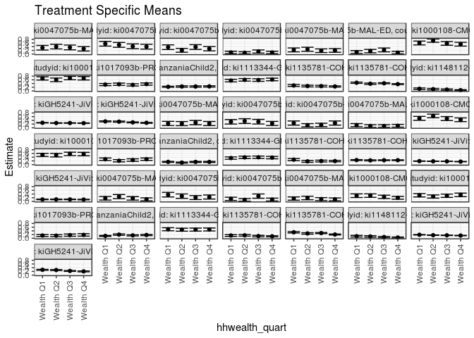

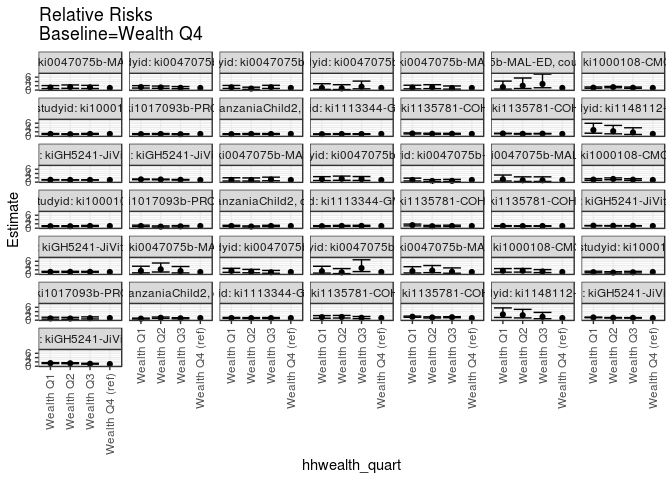

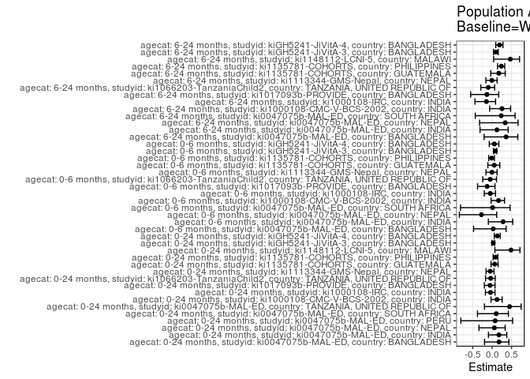

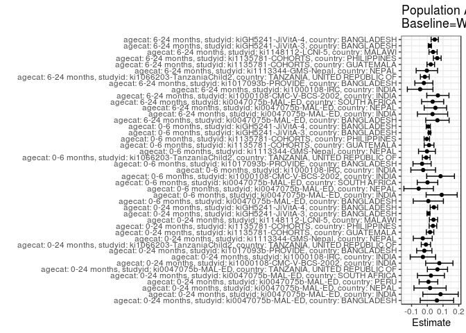

## Results Table

### Parameter: TSM

| agecat | studyid | country | intervention_level | baseline_level | estimate | ci_lower | ci_upper |
| --- | --- | --- | --- | --- | --- | --- | --- |
| 0-24 months | ki0047075b-MAL-ED | BANGLADESH | Wealth Q4 | NA | 0.2859788 | 0.1661164 | 0.4058411 |
| 0-24 months | ki0047075b-MAL-ED | BANGLADESH | Wealth Q1 | NA | 0.3448248 | 0.2198335 | 0.4698161 |
| 0-24 months | ki0047075b-MAL-ED | BANGLADESH | Wealth Q2 | NA | 0.4037903 | 0.2789457 | 0.5286349 |
| 0-24 months | ki0047075b-MAL-ED | BANGLADESH | Wealth Q3 | NA | 0.3604074 | 0.2314032 | 0.4894117 |
| 0-24 months | ki0047075b-MAL-ED | INDIA | Wealth Q4 | NA | 0.4009536 | 0.2716527 | 0.5302544 |
| 0-24 months | ki0047075b-MAL-ED | INDIA | Wealth Q1 | NA | 0.5609943 | 0.4339336 | 0.6880550 |
| 0-24 months | ki0047075b-MAL-ED | INDIA | Wealth Q2 | NA | 0.4980234 | 0.3680758 | 0.6279709 |
| 0-24 months | ki0047075b-MAL-ED | INDIA | Wealth Q3 | NA | 0.4201068 | 0.2905845 | 0.5496290 |
| 0-24 months | ki0047075b-MAL-ED | NEPAL | Wealth Q4 | NA | 0.2918034 | 0.1745497 | 0.4090571 |
| 0-24 months | ki0047075b-MAL-ED | NEPAL | Wealth Q1 | NA | 0.3738122 | 0.2486874 | 0.4989369 |
| 0-24 months | ki0047075b-MAL-ED | NEPAL | Wealth Q2 | NA | 0.2055455 | 0.1016351 | 0.3094559 |
| 0-24 months | ki0047075b-MAL-ED | NEPAL | Wealth Q3 | NA | 0.3828691 | 0.2552939 | 0.5104444 |
| 0-24 months | ki0047075b-MAL-ED | PERU | Wealth Q4 | NA | 0.0882353 | 0.0206961 | 0.1557745 |
| 0-24 months | ki0047075b-MAL-ED | PERU | Wealth Q1 | NA | 0.0882353 | 0.0206961 | 0.1557745 |
| 0-24 months | ki0047075b-MAL-ED | PERU | Wealth Q2 | NA | 0.0704225 | 0.0107991 | 0.1300460 |
| 0-24 months | ki0047075b-MAL-ED | PERU | Wealth Q3 | NA | 0.1384615 | 0.0543427 | 0.2225804 |
| 0-24 months | ki0047075b-MAL-ED | SOUTH AFRICA | Wealth Q4 | NA | 0.1986334 | 0.1006994 | 0.2965675 |
| 0-24 months | ki0047075b-MAL-ED | SOUTH AFRICA | Wealth Q1 | NA | 0.2274280 | 0.1220030 | 0.3328529 |
| 0-24 months | ki0047075b-MAL-ED | SOUTH AFRICA | Wealth Q2 | NA | 0.2601569 | 0.1505472 | 0.3697665 |
| 0-24 months | ki0047075b-MAL-ED | SOUTH AFRICA | Wealth Q3 | NA | 0.1841226 | 0.0867780 | 0.2814673 |
| 0-24 months | ki0047075b-MAL-ED | TANZANIA, UNITED REPUBLIC OF | Wealth Q4 | NA | 0.0793651 | 0.0124835 | 0.1462467 |
| 0-24 months | ki0047075b-MAL-ED | TANZANIA, UNITED REPUBLIC OF | Wealth Q1 | NA | 0.1111111 | 0.0333521 | 0.1888701 |
| 0-24 months | ki0047075b-MAL-ED | TANZANIA, UNITED REPUBLIC OF | Wealth Q2 | NA | 0.1612903 | 0.0695559 | 0.2530248 |
| 0-24 months | ki0047075b-MAL-ED | TANZANIA, UNITED REPUBLIC OF | Wealth Q3 | NA | 0.2258065 | 0.1215230 | 0.3300899 |
| 0-24 months | ki1000108-CMC-V-BCS-2002 | INDIA | Wealth Q4 | NA | 0.5348886 | 0.4335007 | 0.6362766 |
| 0-24 months | ki1000108-CMC-V-BCS-2002 | INDIA | Wealth Q1 | NA | 0.6002061 | 0.4972740 | 0.7031381 |
| 0-24 months | ki1000108-CMC-V-BCS-2002 | INDIA | Wealth Q2 | NA | 0.7276694 | 0.6387787 | 0.8165600 |
| 0-24 months | ki1000108-CMC-V-BCS-2002 | INDIA | Wealth Q3 | NA | 0.5789699 | 0.4780592 | 0.6798806 |
| 0-24 months | ki1000108-IRC | INDIA | Wealth Q4 | NA | 0.6839334 | 0.5911868 | 0.7766800 |
| 0-24 months | ki1000108-IRC | INDIA | Wealth Q1 | NA | 0.6772708 | 0.5887188 | 0.7658228 |

[output cut: 142 more lines]

### Parameter: E(Y)

| agecat | studyid | country | intervention_level | baseline_level | estimate | ci_lower | ci_upper |
| --- | --- | --- | --- | --- | --- | --- | --- |
| 0-24 months | ki0047075b-MAL-ED | BANGLADESH | NA | NA | 0.3471074 | 0.2870050 | 0.4072099 |
| 0-24 months | ki0047075b-MAL-ED | INDIA | NA | NA | 0.4851064 | 0.4210714 | 0.5491414 |
| 0-24 months | ki0047075b-MAL-ED | NEPAL | NA | NA | 0.3093220 | 0.2502261 | 0.3684179 |
| 0-24 months | ki0047075b-MAL-ED | PERU | NA | NA | 0.0955882 | 0.0605817 | 0.1305947 |
| 0-24 months | ki0047075b-MAL-ED | SOUTH AFRICA | NA | NA | 0.2217899 | 0.1708981 | 0.2726816 |
| 0-24 months | ki0047075b-MAL-ED | TANZANIA, UNITED REPUBLIC OF | NA | NA | 0.1440000 | 0.1003920 | 0.1876080 |
| 0-24 months | ki1000108-CMC-V-BCS-2002 | INDIA | NA | NA | 0.6112601 | 0.5617242 | 0.6607959 |
| 0-24 months | ki1000108-IRC | INDIA | NA | NA | 0.6560976 | 0.6100625 | 0.7021326 |
| 0-24 months | ki1017093b-PROVIDE | BANGLADESH | NA | NA | 0.3514286 | 0.3160364 | 0.3868207 |
| 0-24 months | ki1066203-TanzaniaChild2 | TANZANIA, UNITED REPUBLIC OF | NA | NA | 0.2365772 | 0.2195142 | 0.2536402 |
| 0-24 months | ki1113344-GMS-Nepal | NEPAL | NA | NA | 0.5903790 | 0.5535526 | 0.6272054 |
| 0-24 months | ki1135781-COHORTS | GUATEMALA | NA | NA | 0.2612827 | 0.2370438 | 0.2855216 |
| 0-24 months | ki1135781-COHORTS | PHILIPPINES | NA | NA | 0.4037451 | 0.3863123 | 0.4211779 |
| 0-24 months | ki1148112-LCNI-5 | MALAWI | NA | NA | 0.0807834 | 0.0620863 | 0.0994804 |
| 0-24 months | kiGH5241-JiVitA-3 | BANGLADESH | NA | NA | 0.2579831 | 0.2515145 | 0.2644516 |
| 0-24 months | kiGH5241-JiVitA-4 | BANGLADESH | NA | NA | 0.3101161 | 0.2957091 | 0.3245231 |
| 0-6 months | ki0047075b-MAL-ED | BANGLADESH | NA | NA | 0.2355372 | 0.1819640 | 0.2891104 |
| 0-6 months | ki0047075b-MAL-ED | INDIA | NA | NA | 0.3234043 | 0.2634696 | 0.3833389 |
| 0-6 months | ki0047075b-MAL-ED | NEPAL | NA | NA | 0.1991525 | 0.1480924 | 0.2502127 |
| 0-6 months | ki0047075b-MAL-ED | SOUTH AFRICA | NA | NA | 0.1089494 | 0.0707821 | 0.1471167 |
| 0-6 months | ki1000108-CMC-V-BCS-2002 | INDIA | NA | NA | 0.5163043 | 0.4651769 | 0.5674318 |
| 0-6 months | ki1000108-IRC | INDIA | NA | NA | 0.5439024 | 0.4956326 | 0.5921723 |
| 0-6 months | ki1017093b-PROVIDE | BANGLADESH | NA | NA | 0.2585714 | 0.2261125 | 0.2910304 |
| 0-6 months | ki1066203-TanzaniaChild2 | TANZANIA, UNITED REPUBLIC OF | NA | NA | 0.1392617 | 0.1253610 | 0.1531625 |
| 0-6 months | ki1113344-GMS-Nepal | NEPAL | NA | NA | 0.3760933 | 0.3398180 | 0.4123685 |
| 0-6 months | ki1135781-COHORTS | GUATEMALA | NA | NA | 0.2029557 | 0.1782002 | 0.2277111 |
| 0-6 months | ki1135781-COHORTS | PHILIPPINES | NA | NA | 0.2356227 | 0.2205417 | 0.2507038 |
| 0-6 months | kiGH5241-JiVitA-3 | BANGLADESH | NA | NA | 0.1761878 | 0.1705589 | 0.1818167 |
| 0-6 months | kiGH5241-JiVitA-4 | BANGLADESH | NA | NA | 0.1078103 | 0.0979894 | 0.1176312 |
| 6-24 months | ki0047075b-MAL-ED | BANGLADESH | NA | NA | 0.1791667 | 0.1305478 | 0.2277856 |
| 6-24 months | ki0047075b-MAL-ED | INDIA | NA | NA | 0.2723404 | 0.2153029 | 0.3293779 |
| 6-24 months | ki0047075b-MAL-ED | NEPAL | NA | NA | 0.1531915 | 0.1070438 | 0.1993392 |
| 6-24 months | ki0047075b-MAL-ED | SOUTH AFRICA | NA | NA | 0.1450980 | 0.1017849 | 0.1884112 |
| 6-24 months | ki1000108-CMC-V-BCS-2002 | INDIA | NA | NA | 0.2654155 | 0.2205451 | 0.3102860 |
| 6-24 months | ki1000108-IRC | INDIA | NA | NA | 0.3097561 | 0.2649438 | 0.3545684 |
| 6-24 months | ki1017093b-PROVIDE | BANGLADESH | NA | NA | 0.1609756 | 0.1319065 | 0.1900447 |
| 6-24 months | ki1066203-TanzaniaChild2 | TANZANIA, UNITED REPUBLIC OF | NA | NA | 0.1606965 | 0.1446374 | 0.1767556 |
| 6-24 months | ki1113344-GMS-Nepal | NEPAL | NA | NA | 0.4728814 | 0.4325613 | 0.5132014 |
| 6-24 months | ki1135781-COHORTS | GUATEMALA | NA | NA | 0.1291161 | 0.1097606 | 0.1484716 |
| 6-24 months | ki1135781-COHORTS | PHILIPPINES | NA | NA | 0.2666429 | 0.2502871 | 0.2829988 |
| 6-24 months | ki1148112-LCNI-5 | MALAWI | NA | NA | 0.0782609 | 0.0596958 | 0.0968259 |
| 6-24 months | kiGH5241-JiVitA-3 | BANGLADESH | NA | NA | 0.1638036 | 0.1576801 | 0.1699271 |
| 6-24 months | kiGH5241-JiVitA-4 | BANGLADESH | NA | NA | 0.2472801 | 0.2337480 | 0.2608122 |

### Parameter: RR

| agecat | studyid | country | intervention_level | baseline_level | estimate | ci_lower | ci_upper |
| --- | --- | --- | --- | --- | --- | --- | --- |
| 0-24 months | ki0047075b-MAL-ED | BANGLADESH | Wealth Q4 | Wealth Q4 | 1.0000000 | 1.0000000 | 1.0000000 |
| 0-24 months | ki0047075b-MAL-ED | BANGLADESH | Wealth Q1 | Wealth Q4 | 1.2057704 | 0.6927636 | 2.0986703 |
| 0-24 months | ki0047075b-MAL-ED | BANGLADESH | Wealth Q2 | Wealth Q4 | 1.4119590 | 0.8382435 | 2.3783401 |
| 0-24 months | ki0047075b-MAL-ED | BANGLADESH | Wealth Q3 | Wealth Q4 | 1.2602593 | 0.7261579 | 2.1872013 |
| 0-24 months | ki0047075b-MAL-ED | INDIA | Wealth Q4 | Wealth Q4 | 1.0000000 | 1.0000000 | 1.0000000 |
| 0-24 months | ki0047075b-MAL-ED | INDIA | Wealth Q1 | Wealth Q4 | 1.3991502 | 0.9434938 | 2.0748639 |
| 0-24 months | ki0047075b-MAL-ED | INDIA | Wealth Q2 | Wealth Q4 | 1.2420973 | 0.8205314 | 1.8802519 |
| 0-24 months | ki0047075b-MAL-ED | INDIA | Wealth Q3 | Wealth Q4 | 1.0477692 | 0.6704067 | 1.6375435 |
| 0-24 months | ki0047075b-MAL-ED | NEPAL | Wealth Q4 | Wealth Q4 | 1.0000000 | 1.0000000 | 1.0000000 |
| 0-24 months | ki0047075b-MAL-ED | NEPAL | Wealth Q1 | Wealth Q4 | 1.2810414 | 0.7593545 | 2.1611343 |
| 0-24 months | ki0047075b-MAL-ED | NEPAL | Wealth Q2 | Wealth Q4 | 0.7043973 | 0.3693108 | 1.3435179 |
| 0-24 months | ki0047075b-MAL-ED | NEPAL | Wealth Q3 | Wealth Q4 | 1.3120793 | 0.7780608 | 2.2126190 |
| 0-24 months | ki0047075b-MAL-ED | PERU | Wealth Q4 | Wealth Q4 | 1.0000000 | 1.0000000 | 1.0000000 |
| 0-24 months | ki0047075b-MAL-ED | PERU | Wealth Q1 | Wealth Q4 | 1.0000000 | 0.3387470 | 2.9520560 |
| 0-24 months | ki0047075b-MAL-ED | PERU | Wealth Q2 | Wealth Q4 | 0.7981221 | 0.2549050 | 2.4989660 |
| 0-24 months | ki0047075b-MAL-ED | PERU | Wealth Q3 | Wealth Q4 | 1.5692308 | 0.5905794 | 4.1696087 |
| 0-24 months | ki0047075b-MAL-ED | SOUTH AFRICA | Wealth Q4 | Wealth Q4 | 1.0000000 | 1.0000000 | 1.0000000 |
| 0-24 months | ki0047075b-MAL-ED | SOUTH AFRICA | Wealth Q1 | Wealth Q4 | 1.1449631 | 0.5819849 | 2.2525335 |
| 0-24 months | ki0047075b-MAL-ED | SOUTH AFRICA | Wealth Q2 | Wealth Q4 | 1.3097334 | 0.6845682 | 2.5058156 |
| 0-24 months | ki0047075b-MAL-ED | SOUTH AFRICA | Wealth Q3 | Wealth Q4 | 0.9269467 | 0.4497082 | 1.9106391 |
| 0-24 months | ki0047075b-MAL-ED | TANZANIA, UNITED REPUBLIC OF | Wealth Q4 | Wealth Q4 | 1.0000000 | 1.0000000 | 1.0000000 |
| 0-24 months | ki0047075b-MAL-ED | TANZANIA, UNITED REPUBLIC OF | Wealth Q1 | Wealth Q4 | 1.4000000 | 0.4681641 | 4.1865664 |
| 0-24 months | ki0047075b-MAL-ED | TANZANIA, UNITED REPUBLIC OF | Wealth Q2 | Wealth Q4 | 2.0322581 | 0.7352592 | 5.6171658 |
| 0-24 months | ki0047075b-MAL-ED | TANZANIA, UNITED REPUBLIC OF | Wealth Q3 | Wealth Q4 | 2.8451613 | 1.0883485 | 7.4378221 |
| 0-24 months | ki1000108-CMC-V-BCS-2002 | INDIA | Wealth Q4 | Wealth Q4 | 1.0000000 | 1.0000000 | 1.0000000 |
| 0-24 months | ki1000108-CMC-V-BCS-2002 | INDIA | Wealth Q1 | Wealth Q4 | 1.1221141 | 0.8686881 | 1.4494730 |
| 0-24 months | ki1000108-CMC-V-BCS-2002 | INDIA | Wealth Q2 | Wealth Q4 | 1.3604128 | 1.0869597 | 1.7026602 |
| 0-24 months | ki1000108-CMC-V-BCS-2002 | INDIA | Wealth Q3 | Wealth Q4 | 1.0824121 | 0.8366136 | 1.4004266 |
| 0-24 months | ki1000108-IRC | INDIA | Wealth Q4 | Wealth Q4 | 1.0000000 | 1.0000000 | 1.0000000 |
| 0-24 months | ki1000108-IRC | INDIA | Wealth Q1 | Wealth Q4 | 0.9902585 | 0.8205178 | 1.1951135 |

[output cut: 142 more lines]

### Parameter: PAR

| agecat | studyid | country | intervention_level | baseline_level | estimate | ci_lower | ci_upper |
| --- | --- | --- | --- | --- | --- | --- | --- |
| 0-24 months | ki0047075b-MAL-ED | BANGLADESH | Wealth Q4 | NA | 0.0611287 | -0.0452426 | 0.1675000 |
| 0-24 months | ki0047075b-MAL-ED | INDIA | Wealth Q4 | NA | 0.0841528 | -0.0283268 | 0.1966324 |
| 0-24 months | ki0047075b-MAL-ED | NEPAL | Wealth Q4 | NA | 0.0175187 | -0.0847825 | 0.1198198 |
| 0-24 months | ki0047075b-MAL-ED | PERU | Wealth Q4 | NA | 0.0073529 | -0.0518605 | 0.0665664 |
| 0-24 months | ki0047075b-MAL-ED | SOUTH AFRICA | Wealth Q4 | NA | 0.0231564 | -0.0626080 | 0.1089208 |
| 0-24 months | ki0047075b-MAL-ED | TANZANIA, UNITED REPUBLIC OF | Wealth Q4 | NA | 0.0646349 | 0.0004450 | 0.1288248 |
| 0-24 months | ki1000108-CMC-V-BCS-2002 | INDIA | Wealth Q4 | NA | 0.0763714 | -0.0104234 | 0.1631663 |
| 0-24 months | ki1000108-IRC | INDIA | Wealth Q4 | NA | -0.0278358 | -0.1087099 | 0.0530383 |
| 0-24 months | ki1017093b-PROVIDE | BANGLADESH | Wealth Q4 | NA | -0.0191378 | -0.0676081 | 0.0293324 |
| 0-24 months | ki1066203-TanzaniaChild2 | TANZANIA, UNITED REPUBLIC OF | Wealth Q4 | NA | -0.0088592 | -0.0384801 | 0.0207617 |
| 0-24 months | ki1113344-GMS-Nepal | NEPAL | Wealth Q4 | NA | -0.0289032 | -0.0890003 | 0.0311939 |
| 0-24 months | ki1135781-COHORTS | GUATEMALA | Wealth Q4 | NA | 0.0174865 | -0.0063894 | 0.0413624 |
| 0-24 months | ki1135781-COHORTS | PHILIPPINES | Wealth Q4 | NA | 0.0358643 | 0.0117059 | 0.0600228 |
| 0-24 months | ki1148112-LCNI-5 | MALAWI | Wealth Q4 | NA | 0.0393087 | 0.0132339 | 0.0653835 |
| 0-24 months | kiGH5241-JiVitA-3 | BANGLADESH | Wealth Q4 | NA | 0.0075389 | -0.0018269 | 0.0169047 |
| 0-24 months | kiGH5241-JiVitA-4 | BANGLADESH | Wealth Q4 | NA | 0.0419189 | 0.0182450 | 0.0655929 |
| 0-6 months | ki0047075b-MAL-ED | BANGLADESH | Wealth Q4 | NA | 0.0064466 | -0.0894933 | 0.1023866 |
| 0-6 months | ki0047075b-MAL-ED | INDIA | Wealth Q4 | NA | 0.0912969 | -0.0075849 | 0.1901787 |
| 0-6 months | ki0047075b-MAL-ED | NEPAL | Wealth Q4 | NA | -0.0550847 | -0.1489240 | 0.0387545 |
| 0-6 months | ki0047075b-MAL-ED | SOUTH AFRICA | Wealth Q4 | NA | 0.0012571 | -0.0641197 | 0.0666339 |
| 0-6 months | ki1000108-CMC-V-BCS-2002 | INDIA | Wealth Q4 | NA | 0.0843595 | -0.0039565 | 0.1726755 |
| 0-6 months | ki1000108-IRC | INDIA | Wealth Q4 | NA | -0.0262031 | -0.1047565 | 0.0523504 |
| 0-6 months | ki1017093b-PROVIDE | BANGLADESH | Wealth Q4 | NA | -0.0333785 | -0.0909777 | 0.0242207 |
| 0-6 months | ki1066203-TanzaniaChild2 | TANZANIA, UNITED REPUBLIC OF | Wealth Q4 | NA | -0.0070149 | -0.0315717 | 0.0175419 |
| 0-6 months | ki1113344-GMS-Nepal | NEPAL | Wealth Q4 | NA | -0.0021345 | -0.0558267 | 0.0515577 |
| 0-6 months | ki1135781-COHORTS | GUATEMALA | Wealth Q4 | NA | 0.0111874 | -0.0198797 | 0.0422545 |
| 0-6 months | ki1135781-COHORTS | PHILIPPINES | Wealth Q4 | NA | -0.0030084 | -0.0202928 | 0.0142761 |
| 0-6 months | kiGH5241-JiVitA-3 | BANGLADESH | Wealth Q4 | NA | 0.0137865 | 0.0063987 | 0.0211744 |
| 0-6 months | kiGH5241-JiVitA-4 | BANGLADESH | Wealth Q4 | NA | 0.0061328 | -0.0070738 | 0.0193394 |
| 6-24 months | ki0047075b-MAL-ED | BANGLADESH | Wealth Q4 | NA | 0.0644126 | -0.0098997 | 0.1387248 |
| 6-24 months | ki0047075b-MAL-ED | INDIA | Wealth Q4 | NA | 0.0333206 | -0.0629569 | 0.1295982 |
| 6-24 months | ki0047075b-MAL-ED | NEPAL | Wealth Q4 | NA | 0.0514966 | -0.0199428 | 0.1229360 |
| 6-24 months | ki0047075b-MAL-ED | SOUTH AFRICA | Wealth Q4 | NA | 0.0339869 | -0.0362597 | 0.1042336 |
| 6-24 months | ki1000108-CMC-V-BCS-2002 | INDIA | Wealth Q4 | NA | 0.0671910 | -0.0034390 | 0.1378209 |
| 6-24 months | ki1000108-IRC | INDIA | Wealth Q4 | NA | -0.0455397 | -0.1270490 | 0.0359697 |
| 6-24 months | ki1017093b-PROVIDE | BANGLADESH | Wealth Q4 | NA | -0.0219273 | -0.0793570 | 0.0355024 |
| 6-24 months | ki1066203-TanzaniaChild2 | TANZANIA, UNITED REPUBLIC OF | Wealth Q4 | NA | -0.0159470 | -0.0442955 | 0.0124016 |
| 6-24 months | ki1113344-GMS-Nepal | NEPAL | Wealth Q4 | NA | -0.0028502 | -0.0709615 | 0.0652611 |
| 6-24 months | ki1135781-COHORTS | GUATEMALA | Wealth Q4 | NA | 0.0220591 | -0.0020245 | 0.0461427 |
| 6-24 months | ki1135781-COHORTS | PHILIPPINES | Wealth Q4 | NA | 0.0632849 | 0.0385848 | 0.0879850 |
| 6-24 months | ki1148112-LCNI-5 | MALAWI | Wealth Q4 | NA | 0.0365942 | 0.0106304 | 0.0625580 |
| 6-24 months | kiGH5241-JiVitA-3 | BANGLADESH | Wealth Q4 | NA | 0.0162480 | 0.0062734 | 0.0262225 |
| 6-24 months | kiGH5241-JiVitA-4 | BANGLADESH | Wealth Q4 | NA | 0.0470740 | 0.0241175 | 0.0700305 |

### Parameter: PAF

| agecat | studyid | country | intervention_level | baseline_level | estimate | ci_lower | ci_upper |
| --- | --- | --- | --- | --- | --- | --- | --- |
| 0-24 months | ki0047075b-MAL-ED | BANGLADESH | Wealth Q4 | NA | 0.1761088 | -0.1953731 | 0.4321465 |
| 0-24 months | ki0047075b-MAL-ED | INDIA | Wealth Q4 | NA | 0.1734729 | -0.0956069 | 0.3764670 |
| 0-24 months | ki0047075b-MAL-ED | NEPAL | Wealth Q4 | NA | 0.0566357 | -0.3394629 | 0.3356022 |
| 0-24 months | ki0047075b-MAL-ED | PERU | Wealth Q4 | NA | 0.0769231 | -0.8048615 | 0.5279023 |
| 0-24 months | ki0047075b-MAL-ED | SOUTH AFRICA | Wealth Q4 | NA | 0.1044071 | -0.3788439 | 0.4182905 |
| 0-24 months | ki0047075b-MAL-ED | TANZANIA, UNITED REPUBLIC OF | Wealth Q4 | NA | 0.4488536 | -0.1993803 | 0.7467339 |
| 0-24 months | ki1000108-CMC-V-BCS-2002 | INDIA | Wealth Q4 | NA | 0.1249410 | -0.0300499 | 0.2566104 |
| 0-24 months | ki1000108-IRC | INDIA | Wealth Q4 | NA | -0.0424263 | -0.1733421 | 0.0738825 |
| 0-24 months | ki1017093b-PROVIDE | BANGLADESH | Wealth Q4 | NA | -0.0544572 | -0.2017750 | 0.0748018 |
| 0-24 months | ki1066203-TanzaniaChild2 | TANZANIA, UNITED REPUBLIC OF | Wealth Q4 | NA | -0.0374474 | -0.1705187 | 0.0804957 |
| 0-24 months | ki1113344-GMS-Nepal | NEPAL | Wealth Q4 | NA | -0.0489570 | -0.1558839 | 0.0480785 |
| 0-24 months | ki1135781-COHORTS | GUATEMALA | Wealth Q4 | NA | 0.0669255 | -0.0287185 | 0.1536771 |
| 0-24 months | ki1135781-COHORTS | PHILIPPINES | Wealth Q4 | NA | 0.0888292 | 0.0270758 | 0.1466630 |
| 0-24 months | ki1148112-LCNI-5 | MALAWI | Wealth Q4 | NA | 0.4865940 | 0.0711724 | 0.7162168 |
| 0-24 months | kiGH5241-JiVitA-3 | BANGLADESH | Wealth Q4 | NA | 0.0292226 | -0.0077629 | 0.0648507 |
| 0-24 months | kiGH5241-JiVitA-4 | BANGLADESH | Wealth Q4 | NA | 0.1351718 | 0.0552100 | 0.2083660 |
| 0-6 months | ki0047075b-MAL-ED | BANGLADESH | Wealth Q4 | NA | 0.0273700 | -0.4786076 | 0.3602027 |
| 0-6 months | ki0047075b-MAL-ED | INDIA | Wealth Q4 | NA | 0.2822996 | -0.0977499 | 0.5307731 |
| 0-6 months | ki0047075b-MAL-ED | NEPAL | Wealth Q4 | NA | -0.2765957 | -0.8436894 | 0.1160677 |
| 0-6 months | ki0047075b-MAL-ED | SOUTH AFRICA | Wealth Q4 | NA | 0.0115385 | -0.8138550 | 0.4613372 |
| 0-6 months | ki1000108-CMC-V-BCS-2002 | INDIA | Wealth Q4 | NA | 0.1633911 | -0.0273092 | 0.3186915 |
| 0-6 months | ki1000108-IRC | INDIA | Wealth Q4 | NA | -0.0481760 | -0.2030660 | 0.0867725 |
| 0-6 months | ki1017093b-PROVIDE | BANGLADESH | Wealth Q4 | NA | -0.1290880 | -0.3754667 | 0.0731585 |
| 0-6 months | ki1066203-TanzaniaChild2 | TANZANIA, UNITED REPUBLIC OF | Wealth Q4 | NA | -0.0503717 | -0.2423085 | 0.1119108 |
| 0-6 months | ki1113344-GMS-Nepal | NEPAL | Wealth Q4 | NA | -0.0056754 | -0.1590613 | 0.1274120 |
| 0-6 months | ki1135781-COHORTS | GUATEMALA | Wealth Q4 | NA | 0.0551225 | -0.1109790 | 0.1963903 |
| 0-6 months | ki1135781-COHORTS | PHILIPPINES | Wealth Q4 | NA | -0.0127677 | -0.0888549 | 0.0580027 |
| 0-6 months | kiGH5241-JiVitA-3 | BANGLADESH | Wealth Q4 | NA | 0.0782490 | 0.0353472 | 0.1192429 |
| 0-6 months | kiGH5241-JiVitA-4 | BANGLADESH | Wealth Q4 | NA | 0.0568853 | -0.0746281 | 0.1723040 |
| 6-24 months | ki0047075b-MAL-ED | BANGLADESH | Wealth Q4 | NA | 0.3595120 | -0.2080619 | 0.6604273 |
| 6-24 months | ki0047075b-MAL-ED | INDIA | Wealth Q4 | NA | 0.1223492 | -0.3121599 | 0.4129748 |
| 6-24 months | ki0047075b-MAL-ED | NEPAL | Wealth Q4 | NA | 0.3361582 | -0.3232314 | 0.6669623 |
| 6-24 months | ki0047075b-MAL-ED | SOUTH AFRICA | Wealth Q4 | NA | 0.2342342 | -0.4339632 | 0.5910654 |
| 6-24 months | ki1000108-CMC-V-BCS-2002 | INDIA | Wealth Q4 | NA | 0.2531538 | -0.0636977 | 0.4756224 |
| 6-24 months | ki1000108-IRC | INDIA | Wealth Q4 | NA | -0.1470178 | -0.4428533 | 0.0881611 |
| 6-24 months | ki1017093b-PROVIDE | BANGLADESH | Wealth Q4 | NA | -0.1362150 | -0.5534721 | 0.1689683 |
| 6-24 months | ki1066203-TanzaniaChild2 | TANZANIA, UNITED REPUBLIC OF | Wealth Q4 | NA | -0.0992366 | -0.2905685 | 0.0637295 |
| 6-24 months | ki1113344-GMS-Nepal | NEPAL | Wealth Q4 | NA | -0.0060273 | -0.1608867 | 0.1281743 |
| 6-24 months | ki1135781-COHORTS | GUATEMALA | Wealth Q4 | NA | 0.1708470 | -0.0368205 | 0.3369202 |
| 6-24 months | ki1135781-COHORTS | PHILIPPINES | Wealth Q4 | NA | 0.2373395 | 0.1397388 | 0.3238670 |
| 6-24 months | ki1148112-LCNI-5 | MALAWI | Wealth Q4 | NA | 0.4675926 | 0.0389644 | 0.7050498 |
| 6-24 months | kiGH5241-JiVitA-3 | BANGLADESH | Wealth Q4 | NA | 0.0991917 | 0.0363803 | 0.1579089 |
| 6-24 months | kiGH5241-JiVitA-4 | BANGLADESH | Wealth Q4 | NA | 0.1903672 | 0.0921297 | 0.2779748 |